# Analiza zbioru Allegro

Bąkała Mateusz

2 marca 2019

W tym dokumencie zajmiemy się omówieniem zbioru danych transakcji z Allegro. Na początek obejrzymy, z jakimi problemami boryka się ten dataset, potem omówimy pojedyncze zmienne, by wreszcie poszukać jakichś zależności pomiędzy kolumnami.

## Badanie stanu danych

Na początek zapoznajmy się z dostarczonym nam zbiorem danych:

| rows | columns | discrete_columns | continuous_columns | all_missing_columns | total_missing_values | total_observations | memory_usage |
| --- | --- | --- | --- | --- | --- | --- | --- |
| 420020 | 14 | 5 | 9 | 0 | 0 | 5880280 | 36169120 |

### Brakujące wartości

Jak mogliśmy zauważyć, nie ma w analizowanym zbiorze brakujących danych. To dobra wiadomość – dzięki temu nie ponieślibyśmy strat na etapie czyszczenia. Poniżej – wizualizacja tego faktu:

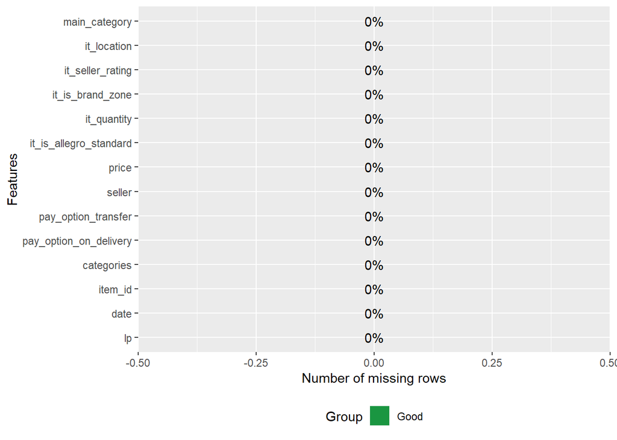

### Histogramy

Skoro już dowiedliśmy, że nie mamy braków danych, możemy przejść do etapu analizy danych ilościowych. Wykorzystajmy funkcję generującą histogramy dla wszystkich kolumn numerycznych, aby ocenić potrzebne kroki.

[figure not shown]

Natychmiast rzuca się w oczy kilka rzeczy do zrobienia. Po pierwsze – zupełnie zbędna kolumna z numerem wiersza. Ponadto mamy całą grupę zero-jedynkowych kolumn, które powinniśmy zapisać jako kategoryczne/logiczne. Również id produktu nie jest liczbą, która ma dla nas znaczenie, więc i tutaj zastosujemy konwersję do faktora. Przy okazji skonwertujemy też kolumnę dat do formatu przechowującego daty na potrzeby późniejszych analiz.

```r
allegro.data <- drop_columns(allegro.data, "lp")
allegro.data$pay_option_on_delivery <- as.logical(allegro.data$pay_option_on_delivery)
allegro.data$pay_option_transfer <- as.logical(allegro.data$pay_option_transfer)
allegro.data$it_is_allegro_standard <- as.logical(allegro.data$it_is_allegro_standard)
allegro.data$it_is_brand_zone <- as.logical(allegro.data$it_is_brand_zone)
allegro.data$item_id <- as.factor(allegro.data$item_id)
allegro.data$date <- as.POSIXct(allegro.data$date)
```

### Wykresy słupkowe

Skoro przenieśliśmy już część kolumn ilościowych do zbioru kolumn jakościowych, przedstawmy te drugie za pomocą wykresów słupkowych:

```
## 5 columns ignored with more than 50 categories.
## date: 38953 categories
## item_id: 332519 categories
## categories: 9020 categories
## seller: 51064 categories
## it_location: 10056 categories
```

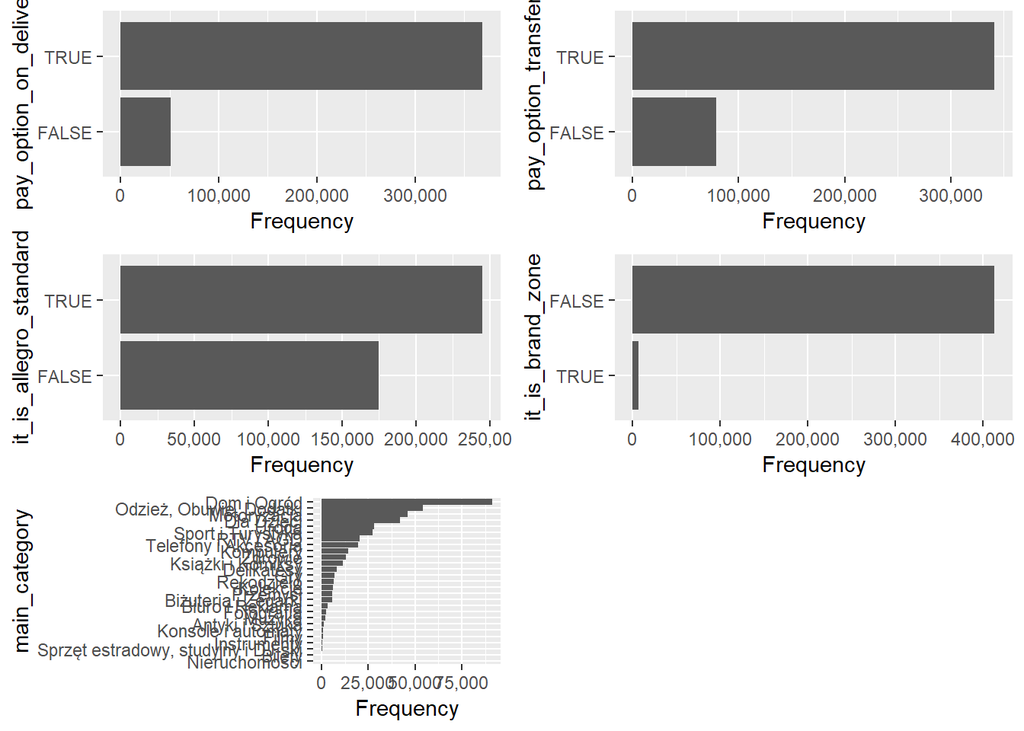

Ponieważ celem tej analizy nie jest oczyszczenie zbioru danych, lecz tylko kosmetyczne przygotowanie go do opisów, nie będziemy dokonywać żadnych manipulacji na kategoriach.

### Sprawdzenie z dataMaid

Pozostaje nam tylko sprawdzić problemy przy użyciu biblioteki dataMaid. Wykorzystamy wygodną funkcję check na naszym datasecie. Przy okazji przefiltrujemy wynikową listę, by w pewnym stopniu ją skrócić.

```r
allegro.check <- check(allegro.data)
```

```
## $date
## $date$identifyLoners
## Note that the following levels have at most five observations: 2016-04-03 00:00:09, 2016-04-03 00:00:16, 2016-04-03 00:00:18, 2016-04-03 00:00:21, 2016-04-03 00:00:34, 2016-04-03 00:00:37, 2016-04-03 00:00:38, 2016-04-03 00:00:42, 2016-04-03 00:00:43, 2016-04-03 00:00:48 (16388 additional values …
##
## $item_id
## $item_id$identifyLoners
## Note that the following levels have at most five observations: 4179878614, 4415896249, 4557755467, 4559715536, 4562875811, 4563075759, 4565018385, 4570482166, 4571727427, 4572473443 (329509 additional values omitted).
##
## $categories
## $categories$identifyLoners
## Note that the following levels have at most five observations: ['Antyki i Sztuka', 'Akcesoria plastyczne', 'Artykuły graficzne'], ['Antyki i Sztuka', 'Akcesoria plastyczne', 'Pozłotnictwo'], ['Antyki i Sztuka', 'Akcesoria plastyczne', 'Przybory rysunkowe', 'Węgiel'], ['Antyki i Sztuka', 'Akcesori…
##
## $pay_option_on_delivery
## NULL
##
## $pay_option_transfer
## NULL
##
## $seller
## $seller$identifyMissing
## The following suspected missing value codes enter as regular values: ...Andy....
## $seller$identifyLoners
## Note that the following levels have at most five observations: ----wojtek----, ---asior---, ---Drobiazg---, ---fanaberia---, ---Siwy---, ---skrecz---, --antiques--, --DIAMOND--, --EXPERT--, --FF-- (37680 additional values omitted).
##
## $price
## $price$identifyOutliers
## Note that the following possible outlier values were detected: 513, 513.99, 514, 515, 516, 516.69, 517, 518, 519, 519.99 (1337 additional values omitted).
##
## $it_is_allegro_standard
## NULL
##
## $it_quantity
## $it_quantity$identifyOutliers
## Note that the following possible outlier values were detected: 16993, 17426, 17435, 17468, 17583, 17743, 18101, 18159, 18278, 18330 (2432 additional values omitted).
##
## $it_is_brand_zone
## NULL
##
## $it_seller_rating
## $it_seller_rating$identifyOutliers
## Note that the following possible outlier values were detected: 178106, 178108, 178109, 178112, 178113, 178115, 178116, 178119, 178120, 178157 (949 additional values omitted).
##
## $it_location
## $it_location$identifyMissing
## The following suspected missing value codes enter as regular values: -, ., .., ..., ...., ....., ........, ........., ............., ............................. (1 additional values omitted).
## $it_location$identifyWhitespace
## The following values appear with prefixed or suffixed white space:  - Ząbki  koło Warszawy,     *,     Dzierżoniów,   WARSZAWA JANKI,    Warszawa,Wrocław,Częstochowa,  @,  _,  18 Miast i Wysyłkowo CAŁA POLSKA,  Cały Kraj,  Chotomów (390 additional values omitted).
## $it_location$identifyLoners
## Note that the following levels have at most five observations: --, ----------, -----------, ---------------, ---------------------, --> SPRZEDAŻ  WYSYŁKOWA <--,  - Ząbki  koło Warszawy,     *,     Dzierżoniów,   WARSZAWA JANKI (6159 additional values omitted).
## $it_location$identifyCaseIssues
## Note that there might be case problems with the following levels:  kraków,  Kraków, @pl, @PL, 18 miast oraz wysyłkowo CAŁA POLSKA, 18 Miast oraz wysyłkowo CAŁA POLSKA, 18 Miast oraz Wysyłkowo CAŁA POLSKA, 18 MIAST oraz wysyłkowo CAŁA POLSKA, 21-080 Garbów, Zagrody 115c, 21-080 Garbów, Zagrody 115…
##
## $main_category
## $main_category$identifyLoners
## Note that the following levels have at most five observations: Nieruchomości.
```

Jak możemy zauważyć, kolumna it_location wymaga szczególnej troski z uwagi na typowe dla gatunku ludzkiego niekonsekwencje w zapisie. Poza tym mamy jedynie potencjalne wartości odstające oraz kategorie z małą liczbą obserwacji. Zwróćmy też uwagę na interesujące, choć fałszywe spostrzeżenie, że “…Andy….” mogłoby być sposobem na zapis brakujących danych w kolumnie id sprzedawcy.

## Analizy jednowymiarowe

Możemy przejść do następnego punktu naszego dokumentu, w którym zajmiemy się nieco dokładniej analizami pojedynczych kolumn. Wykorzystajmy funkcję table dla zmiennych kateogrycznych i summary dla ilościowych. Wyniki zilustrujmy przy użyciu wykresów.

Główne kategorie produktów

| Kategoria | Ilosc |
| --- | --- |
| Antyki i Sztuka | 1214 |
| Bilety | 119 |
| Biuro i Reklama | 3194 |
| Biżuteria i Zegarki | 5808 |
| Delikatesy | 8074 |
| Dla Dzieci | 42107 |
| Dom i Ogród | 91042 |
| Filmy | 1005 |
| Fotografia | 2381 |
| Gry | 7150 |
| Instrumenty | 617 |
| Kolekcje | 6146 |
| Komputery | 14491 |
| Konsole i automaty | 1053 |
| Książki i Komiksy | 11572 |
| Motoryzacja | 45941 |
| Muzyka | 1961 |
| Nieruchomości | 2 |
| Odzież, Obuwie, Dodatki | 54257 |
| Przemysł | 5959 |
| Rękodzieło | 6574 |
| RTV i AGD | 20341 |
| Sport i Turystyka | 27532 |
| Sprzęt estradowy, studyjny i DJ-ski | 413 |
| Telefony i Akcesoria | 19805 |
| Uroda | 28096 |
| Zdrowie | 13166 |

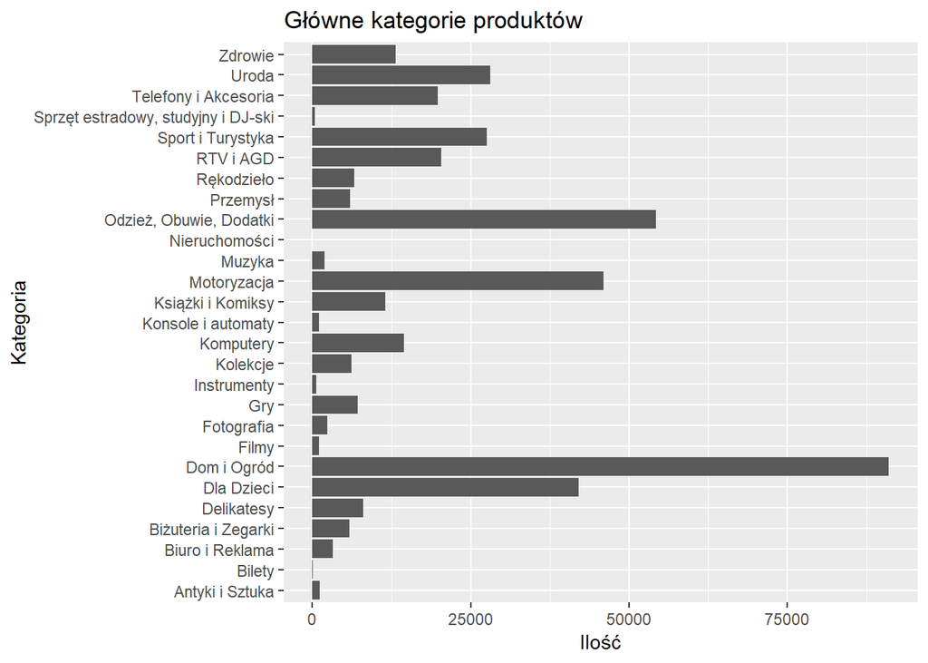

Liczności każdej z kategorii dość dobrze odzwierciedlają częstotliwość potrzeb przeciętnego Kowalskiego. Dwoma odchyleniami od spodziewanych rezultatów są kategorie “Motoryzacja” i “Filmy”. W pierwszym przypadku znacząca liczba ofert jest prawdopodobnie pochodną faktu, że – w przeciwieństwie do pozostałych kategorii – Allegro jest jednym z nielicznych mediów, które pozwala na dotarcie do wielu potencjalnych kupców. Z kolei ofert filmów jest stosunkowo niewiele, ale to wynika z faktu, że kilka innych środków pozyskiwania filmów jest bardziej popularnych (jak chociażby telewizja czy platformy z filmami).

```
##    Min. 1st Qu.  Median    Mean 3rd Qu.    Max.
##      -1    1581    6711   20403   21007  292074
```

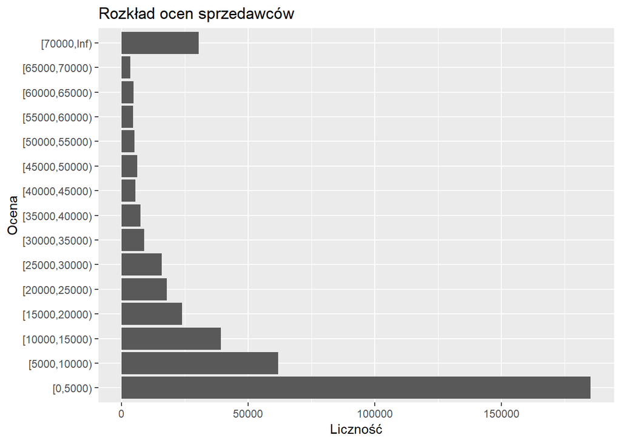

Jak można było się spodziewać, rozkład ocen sprzedawców jest skośny, ponieważ rejestracja nowych użytkowników jest stale otwarta, tacy użytkownicy zaczynają w punkcie 0, a zdobycie dużej ilości punktów wymaga czasu.

## Analizy dwuwymiarowe

Popularność płatności przy odbiorze w zależności od kategorii

|  | FALSE | TRUE |
| --- | --- | --- |
| Antyki i Sztuka | 0.3970346 | 0.6029654 |
| Bilety | 0.8907563 | 0.1092437 |
| Biuro i Reklama | 0.1014402 | 0.8985598 |
| Biżuteria i Zegarki | 0.2100551 | 0.7899449 |
| Delikatesy | 0.0803815 | 0.9196185 |
| Dla Dzieci | 0.1583347 | 0.8416653 |
| Dom i Ogród | 0.0548209 | 0.9451791 |
| Filmy | 0.3532338 | 0.6467662 |
| Fotografia | 0.1562369 | 0.8437631 |
| Gry | 0.7184615 | 0.2815385 |
| Instrumenty | 0.1037277 | 0.8962723 |
| Kolekcje | 0.3226489 | 0.6773511 |
| Komputery | 0.2295908 | 0.7704092 |
| Konsole i automaty | 0.4605888 | 0.5394112 |
| Książki i Komiksy | 0.2122364 | 0.7877636 |
| Motoryzacja | 0.0280795 | 0.9719205 |
| Muzyka | 0.3977562 | 0.6022438 |
| Nieruchomości | 0.0000000 | 1.0000000 |
| Odzież, Obuwie, Dodatki | 0.1492526 | 0.8507474 |
| Przemysł | 0.0318845 | 0.9681155 |
| Rękodzieło | 0.1845148 | 0.8154852 |
| RTV i AGD | 0.0744801 | 0.9255199 |
| Sport i Turystyka | 0.0595670 | 0.9404330 |
| Sprzęt estradowy, studyjny i DJ-ski | 0.0653753 | 0.9346247 |
| Telefony i Akcesoria | 0.1636455 | 0.8363545 |
| Uroda | 0.1144291 | 0.8855709 |
| Zdrowie | 0.1083852 | 0.8916148 |

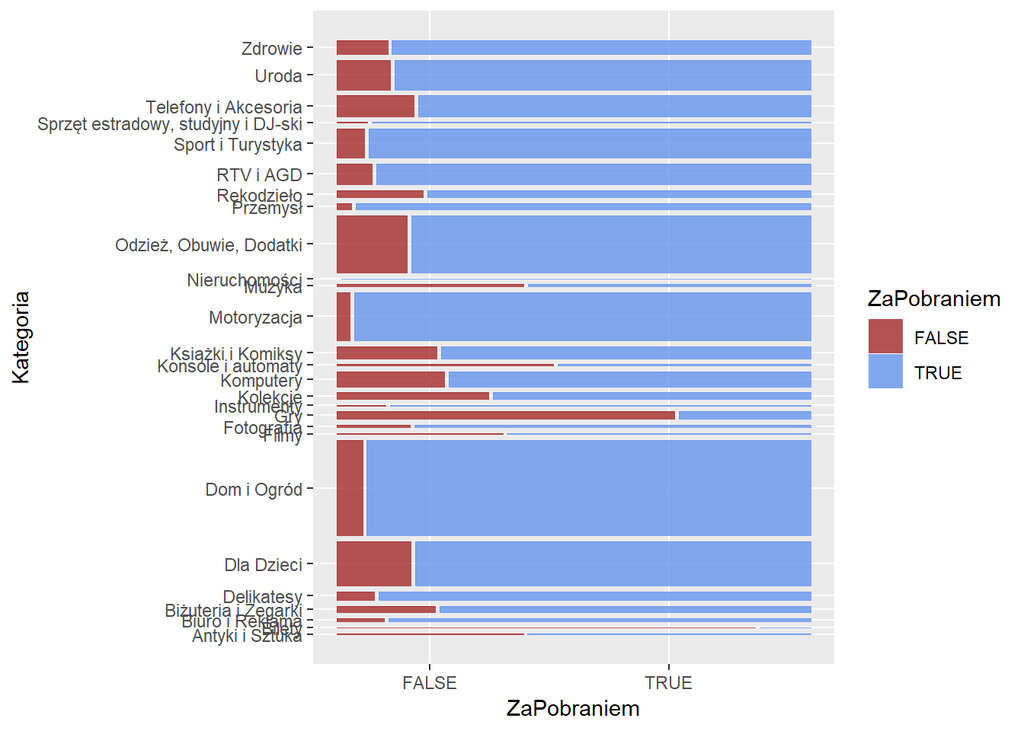

Jak widzimy, na Allegro dominuje opcja płatności za pobraniem, szczególnie w tych dominujących kategoriach. Jedynie gry oraz bilety kupowane są częściej z płatnością z góry, co może być związane z faktem, że powyższe dość często sprzedawane są w formie cyfrowej, w przypadku której trudno mówić o czynności “pobierania”.

Porównanie liczby sprzedawców markowych i niezależnych

| W strefie marek | Liczba |
| --- | --- |
| FALSE | 413008 |
| TRUE | 7012 |

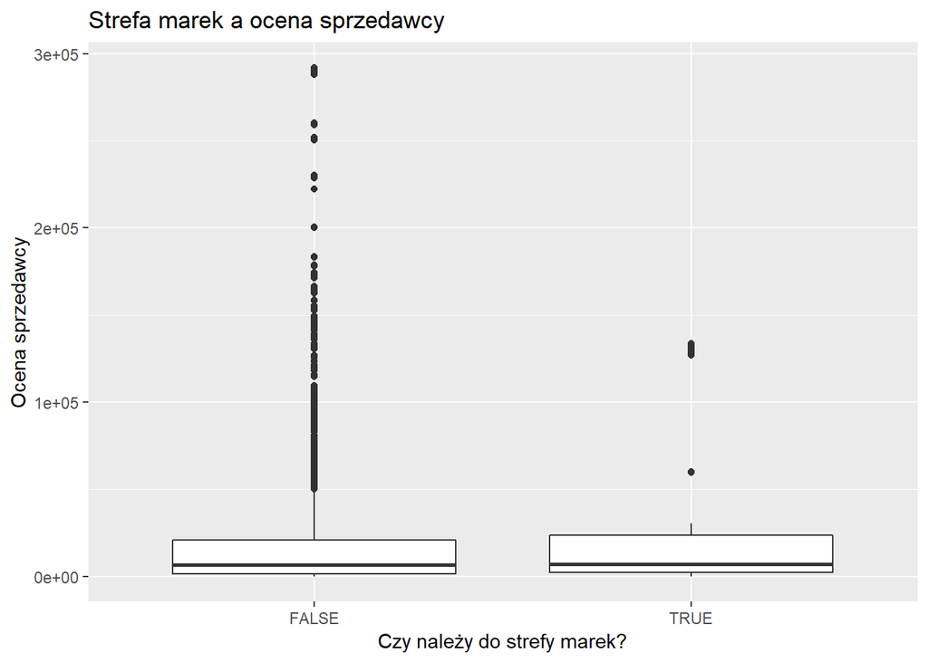

Żadna znacząca prawidłowość nie rzuca się w oczy, wprawdzie wszyscy najwyżej oceniani sprzedawcy pochodzą spoza strefy marek, jednak przeciętne oceny markowych sprzedawców są nieznacznie wyższe, co widać po nieco wyższym położeniu “ciała” prawej skrzynki. Ich wąs jest jednak znacznie krótszy, ponieważ próbka markowych sprzedawców jest znacząco mniejsza.